# FAS1003: Visualisation des données

# Cours 7: Manipulation des données et nouveaux graphiques

## Plan de match

1. Manipulation des banques de données: un peu plus loin
2. Manipulation des données textuelles
3. Nouveaux types de graphiques

# Manipulation des banques de données: un peu plus loin

## Les données du jour

```r
library(tidytuesdayR)
d <- tt_load('2021-10-19')
citrouilles <- d$pumpkins

# ou
citrouilles <- read_csv('https://raw.githubusercontent.com/rfordatascience/tidytuesday/master/data/2021/2021-10-19/pumpkins.csv')
```

## distinct()

La fonction `distinct()` permet de sélectionner les lignes qui ont des valeurs uniques aux colonnes spécifiées.

```r
demo = citrouilles %>%
  distinct(state_prov, country)
```

## drop_na()

`drop_na()` supprime les lignes qui ont des valeurs manquantes à la colonne spécifiée.

```r
demo2 = citrouilles %>%
  drop_na(pollinator_father)
```

## reorder()

`reorder()` permet de placer les éléments en ordre croissant (ou décroissant).

```r
dat = citrouilles %>%
  filter(country == "United States" |
         country == "Canada" |
         country == "France") %>%
  mutate(est_weight = as.numeric(est_weight)) %>%
  group_by(country) %>%
  summarise(poids_total = sum(est_weight, na.rm = T))
```

## reorder()

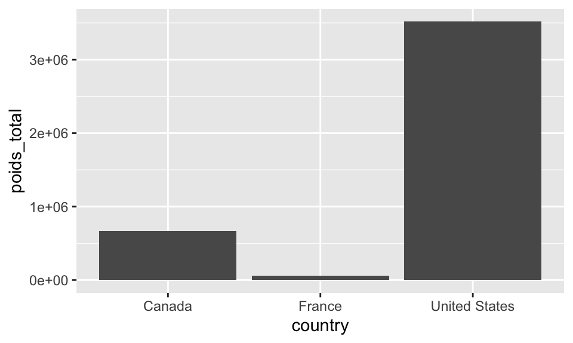

```r
ggplot(data = dat, aes(x = country,
                       y = poids_total))  +
  geom_col()
```

## reorder()

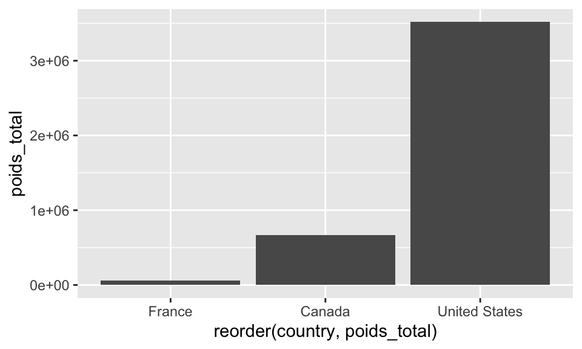

```r
ggplot(data = dat, aes(x = reorder(country, poids_total),
                       y = poids_total))  +
  geom_col()
```

## reorder()

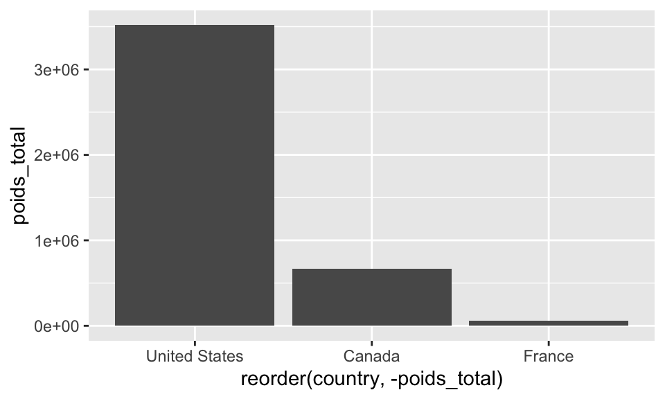

```r
ggplot(data = dat, aes(x = reorder(country, -poids_total),
                       y = poids_total))  +
  geom_col()
```

# Exercice 1

## Exercice 1: consignes

1. Combien de valeurs uniques y a-t-il de la variable `city` dans la banque de données `citrouilles`?
2. Combien de valeurs manquantes y a-t-il dans la variable `seed_mother`?

## Exercice 1: corrigé

1. Combien de valeurs uniques y a-t-il de la variable `city`?

```r
d = citrouilles %>%
  distinct(city)

nrow(d)
```

```
## [1] 3219
```

2. Combien de valeurs manquantes y a-t-il dans la variable `seed_mother`?

```r
d = citrouilles %>%
  drop_na(seed_mother)

28065-19528
```

```
## [1] 8537
```

# Manipulation de données textuelles

## Le package `stringr`

- Données de type “caractère” (character string): une valeur inscrite entre parenthèses.
- Peut être des lettres, des chiffres, ou une combinaison des 2.
- Un chiffre inscrit entre parenthèses n’est pas traité comme une valeur numérique, mais comme un caractère.

## str_length

Pour calculer le nombre de caractères dans un string.

```r
d = "allo"
str_length(d)
```

```
## [1] 4
```

## str_length

```r
citrouilles2 = citrouilles %>%
  mutate(long = str_length(grower_name))
```

## str_detect

Détecter certaines lettres, mots, expressions, patterns.

```r
str_detect(d, "a")
```

```
## [1] TRUE
```

```r
str_detect(d, "f")
```

```
## [1] FALSE
```

## str_detect

```r
citrouille3 = citrouilles %>%
  mutate(festival_b = ifelse(str_detect(gpc_site, "Fest|Festival"),
                             1, 0))

table(citrouille3$festival_b)
```

```
##
##     0     1
## 24263  3802
```

## str_remove et str_remove_all

Retirer des éléments d’un string.

```r
str_remove(d, "l")
```

```
## [1] "alo"
```

```r
str_remove_all(d, "l")
```

```
## [1] "ao"
```

## str_remove et str_remove_all

```r
citrouilles4 = citrouilles %>%
  mutate(pays_n = str_remove_all(country, "United"))
```

## str_replace et str_replace_all

Remplacer un élément d’un string par un autre.

```r
str_replace(d, "a", "4")
```

```
## [1] "4llo"
```

```r
str_replace_all(d, "l", "y")
```

```
## [1] "ayyo"
```

## str_replace et str_replace_all

```r
citrouilles5 = citrouilles %>%
  mutate(site = str_replace_all(gpc_site, "Fest", "Festival"))
```

## str_extract et str_extract_all

Extraire un élément d’un string.

```r
str_extract(d, "a")
```

```
## [1] "a"
```

```r
str_extract(d, "x")
```

```
## [1] NA
```

## str_to_upper, str_to_lower

Mettre tout en majuscules ou en minuscules.

```r
str_to_upper(d)
```

```
## [1] "ALLO"
```

## et bien plus!

Voir la documentation du package.

https://cran.r-project.org/web/packages/stringr/vignettes/stringr.html

# Exercice 2

## Exercice 2: corrigé

1. Remplacez tout les tirets (-) de la variable `id` par des barres de soulignement (_). Enregistrez le résultat dans une nouvelle variable.

```r
q1 = citrouilles %>%
  mutate(id_n = str_replace_all(id, "-", "_"))
```

## Exercice 2: corrigé

```r
q2 = citrouilles %>%
  filter(str_detect(grower_name, "Jack"))
```

## Exercice 2: corrigé

3. Retirez les suffixes “.0” de la variable `ott`. Enregistrez le résultat dans une nouvelle variable.

```r
q3 = citrouilles %>%
  mutate(ott_n = str_remove_all(ott, ".0"))
```

# Expressions régulières (Regular expressions ou Regex)

## Expressions régulières

- Cibler les lettres/mots en fonction de leur position.
- Cibler les chiffres seulement.
- Cibler un caractère spécial en particulier.
- Cibler les éléments qui viennent avant la virgule.
- Etc.

## Expressions régulières: quelques trucs de base

- Les regex sont presqu’infinis! Il ne sert à rien de les apprendre par coeur.
- Pour devenir maître dans l’art du regex, il est préférable de s’entraîner à partir de problèmes concrets.
- Voici tout de même certaines commandes qu’il peut être utile d’avoir au bout des doigts.

## Expressions régulières: quelques trucs de base

Les chiffres et les lettres

```r
# chiffres (digits)
regex = citrouilles %>%
  mutate(seed_mother_n = str_remove_all(seed_mother, "\\d"),
         seed_mother_n2 = str_remove_all(seed_mother, "[0-9]"))

# lettres
regex2 = citrouilles %>%
  mutate(seed_mother_n = str_remove_all(seed_mother, "[aA-zZ]"),
         seed_mother_n2 = str_remove_all(seed_mother, "[:alpha:]"))
```

## Expressions régulières: quelques trucs de base

“Avant” ou “après” un certain caractère

```r
regex3 = citrouilles %>%
  mutate(grower_name_av = str_remove_all(grower_name, ",.*"),
         grower_name_ap = str_remove_all(grower_name, ".*,"))

# .* signifie "tout le reste"
```

## Expressions régulières: quelques trucs de base

Pluriels

```r
exemple = c("citrouilles", "citrouille", "halloween")

str_detect(exemple, "\\bcitrouilles?\\b")
```

```
## [1]  TRUE  TRUE FALSE
```

```r
# \\b sont les limites du mot
# s? signifie 1 ou 0 s
```

## Expressions régulières: quelques trucs de base

“Échapper” un caractère

```r
# Le point veut dire quelque chose en regex
# On le cible en ajoutant une \ devant (2 fois avec stringr)
regex5 = citrouilles %>%
  mutate(seed_mother_n = str_remove_all(seed_mother, "\\."))
```

## Expressions régulières: ressources

- https://www.lucaswillems.com/fr/articles/25/tutoriel-pour-maitriser-les-expressions-regulieres
- https://cran.r-project.org/web/packages/stringr/vignettes/regular-expressions.html
- https://docs.pexip.com/admin/regex_reference.htm

# Nouveaux types de graphiques

## À date

- `geom_bar()`
- `geom_col()`
- `geom_histogram()`
- `geom_point()`
- `geom_density()`

## Boîtes à moustaches

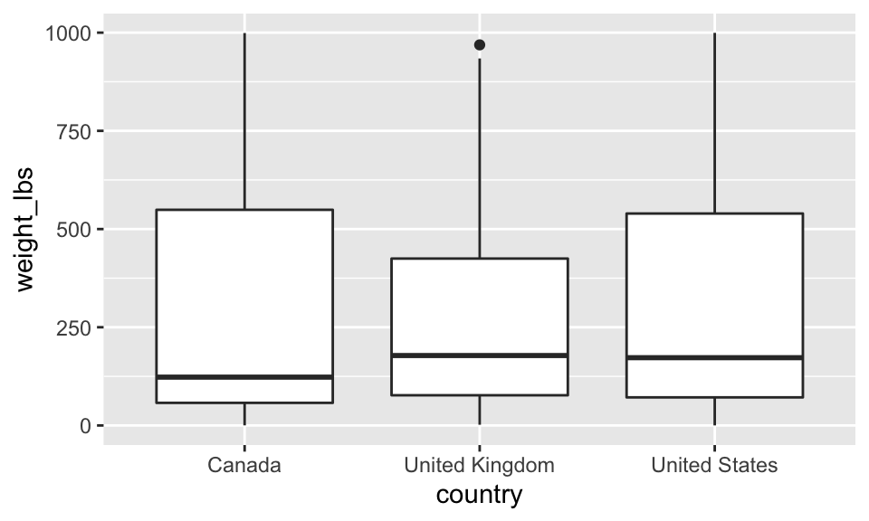

```r
dat_can_united = citrouilles %>%
  filter(str_detect(country, "Canada|United")) %>%
  mutate(weight_lbs = as.numeric(weight_lbs))

ggplot(data = dat_can_united, aes(x = country, y = weight_lbs)) +
  geom_boxplot()
```

## Alternative: Graphiques “violons”

- `geom_violin()`
- Comme le graphique à moustache, mais une courbe de densité est ajoutée.

## Alternative: Graphiques “violons”

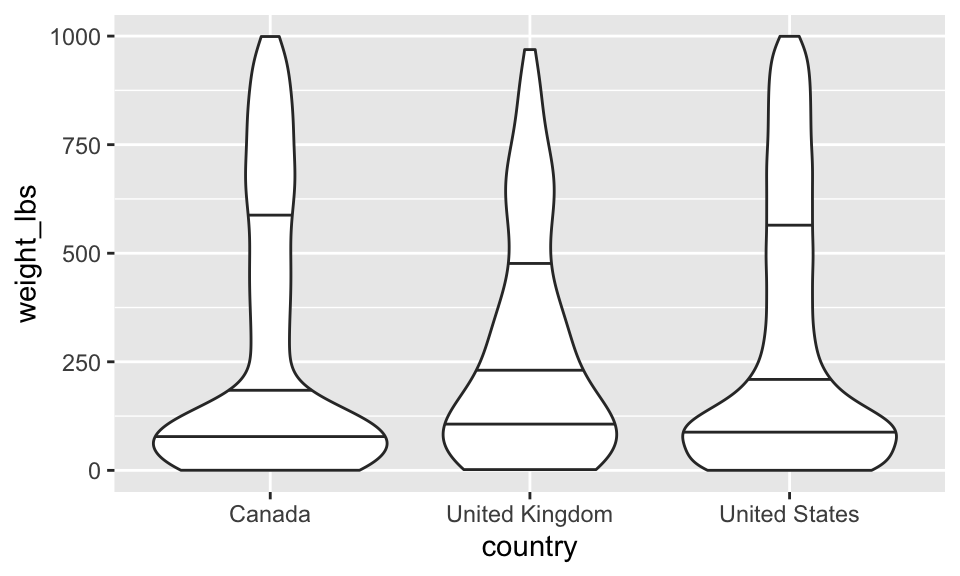

```r
ggplot(data = dat_can_united, aes(x = country, y = weight_lbs)) +
  geom_violin(draw_quantiles = c(0.25, 0.5, 0.75))
```

## Graphiques à barres, mais multivariés

Barres empilées

```r
dat_can_united_self_open = citrouilles %>%
  mutate(pollinator_father = str_to_lower(pollinator_father)) %>%
  filter(str_detect(country, "Canada|United States"),
         str_detect(pollinator_father, "open|self")) %>%
  mutate(pollinator_father = ifelse(str_detect(pollinator_father, "self"), "self", "open"),
         weight_lbs = as.numeric(weight_lbs))
```

## Graphiques à barres, mais multivariés

Barres empilées

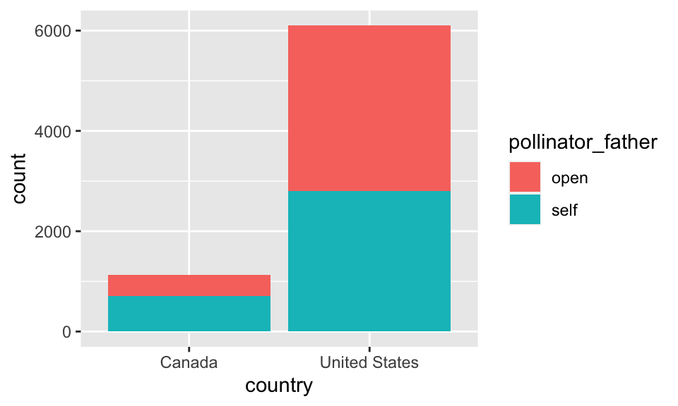

```r
ggplot(data = dat_can_united_self_open, aes(x = country, fill = pollinator_father)) +
  geom_bar()
```

## Graphiques à barres, mais multivariés

Barres groupées

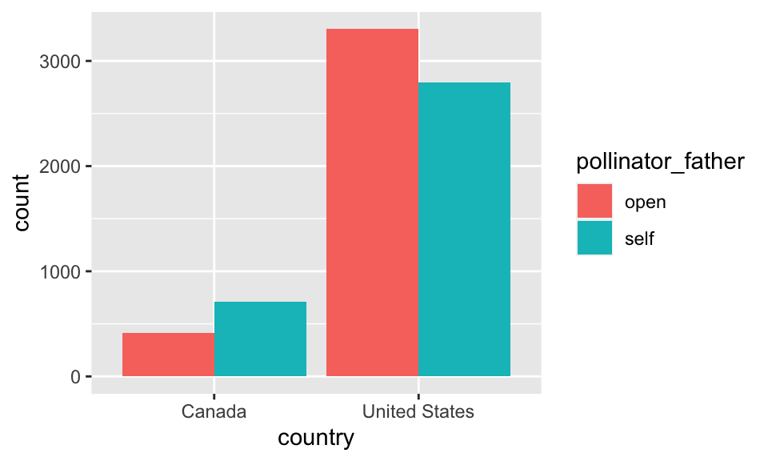

```r
ggplot(data = dat_can_united_self_open, aes(x = country, fill = pollinator_father)) +
  geom_bar(position = "dodge")
```

## Alternative: graphiques d’aire

- `geom_area()`
- Variable x continue (un peu comme les histogrammes!)

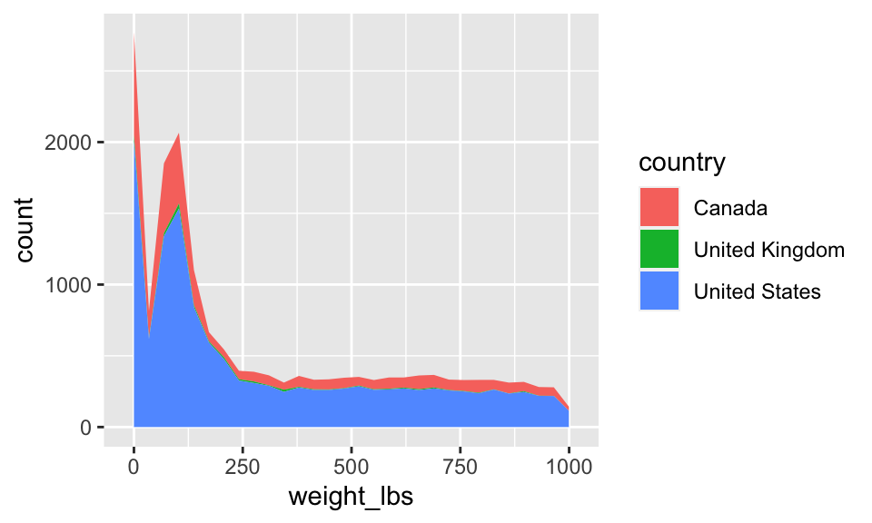

```r
ggplot(data = dat_can_united, aes(x = weight_lbs, fill = country)) +
  geom_area(stat = "bin")
```

## Parenthèse

- Un mot sur “bin”, “count” et “identity”

## Graphiques de densité, mais multivariés

- `geom_density_ridges`
- Plusieurs courbes de densité, une pour chaque catégorie de la variable y.
- La variable y doit être catégorielle (**character** ou **factor**).

```r
table(dat_can_united$id)
```

```
##
## 2013-F 2013-L 2013-P 2013-S 2013-T 2013-W 2014-F 2014-L 2014-P 2014-S 2014-T
##    276    163   1388    121    260    244    296    154   1543    154    258
## 2014-W 2015-F 2015-L 2015-P 2015-S 2015-T 2015-W 2016-F 2016-L 2016-P 2016-S
##    252    282    167   1626    158    279    250    269    196   1434    148
## 2016-T 2016-W 2017-F 2017-L 2017-P 2017-S 2017-T 2017-W 2018-F 2018-L 2018-P
##    290    261    255    141   1301    151    311    240    257    153   1460
## 2018-S 2018-T 2018-W 2019-F 2019-L 2019-P 2019-S 2019-T 2019-W 2020-F 2020-L
##    129    312    277    234    168   1387    135    352    236    196    158
## 2020-P 2020-S 2020-T 2020-W 2021-F 2021-L 2021-P 2021-S 2021-T 2021-W
##   1073    100    257    223    198    130   1032     89    259    201
```

## Graphiques de densité, mais multivariés

```r
dat_can_united = dat_can_united %>%
  mutate(annee = str_remove_all(id, "[aA-zZ]|-"),
         ott = as.numeric(ott))

table(dat_can_united$annee)
```

```
##
## 2013 2014 2015 2016 2017 2018 2019 2020 2021
## 2452 2657 2762 2598 2399 2588 2512 2007 1909
```

## Graphiques de densité, mais multivariés

```r
# install.packages("ggridges")
library(ggridges)

class(dat_can_united$annee)
```

```
## [1] "character"
```

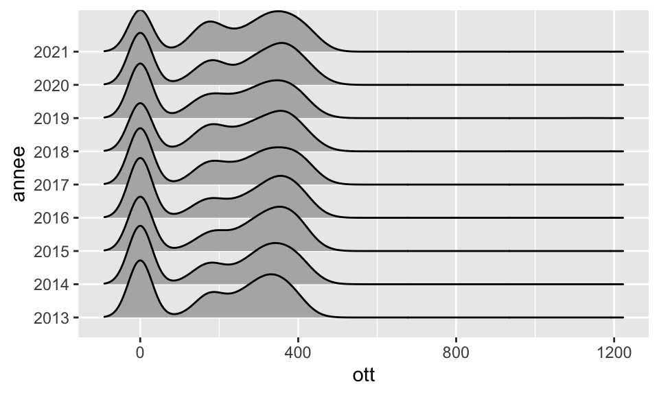

```r
ggplot(data = dat_can_united, aes(x = ott, y = annee)) +
  geom_density_ridges()
```

# Exercice 3

## Exercice 3: consignes

- Créez un graphique qui permet de montrer combien de citrouilles provenait des états de Washington, de la Pennsylvanie, de New York et de l’Oregon par année.
- Soyez créatif, il n’y a pas de limites!

## Exercice 3: corrigé

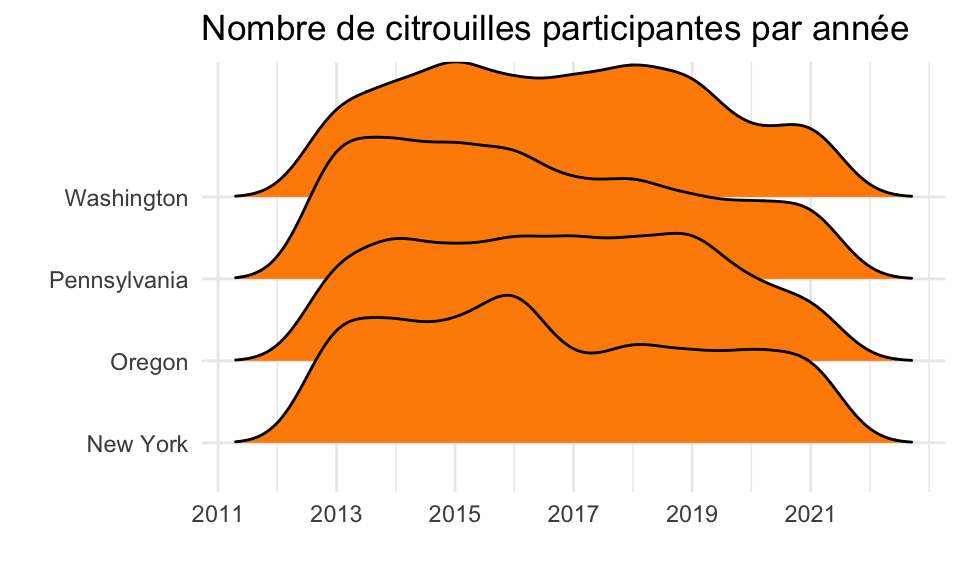

```r
dat = citrouilles %>%
  filter(str_detect(state_prov, "Washington|New York|Oregon|Pennsylvania")) %>%
  mutate(annee = str_remove_all(id, "[aA-zZ]|-"),
         annee = as.numeric(annee))

ggplot(data = dat, aes(x = annee, y = state_prov))+
  geom_density_ridges(fill = "darkorange") +
  scale_x_continuous(breaks = c(2011, 2013, 2015, 2017, 2019, 2021)) +
  theme_minimal() +
  labs(y = "",
       x = "",
       title = "Nombre de citrouilles participantes par année")
```

# Travail pratique 4